## MachineLearningProject

### Sypnosis

For this project we use data from accelerometers on the belt, forearm, arm, and dumbell of 6 participants who quantify how well they do an exercise. They were asked to perform barbell lifts correctly and incorrectly in 5 different ways. More information is available from the website here: http://groupware.les.inf.puc-rio.br/har (see the section on the Weight Lifting Exercise Dataset).

The goal of this project is to predict the manner in which they did the exercise. This is the “classe” variable in the training set. Other variables will be use to predict with.

### Data Processing

First we install libraries and download data files from URL.

```r
#install.packages("caret")
#install.packages("randomForest")
library(caret)
library(randomForest)
```

```r
setwd("C:/DataScientistGit/machine learning")

if(!file.exists("data")){
  dir.create("data")
}

fileurl <- "https://d396qusza40orc.cloudfront.net/predmachlearn/pml-training.csv"
#download.file(fileurl, destfile = "./data/pml-training.csv")
fileurl <- "https://d396qusza40orc.cloudfront.net/predmachlearn/pml-testing.csv"
#download.file(fileurl, destfile = "./data/pml-testing.csv")
```

We upload data and prepare them to keep just columns with no missing data. We also remove time columns because this information is no relevant for this study.

```r
training <- read.table("./data/pml-training.csv", sep=",", header=TRUE)
testing <- read.table("./data/pml-testing.csv", sep=",", header=TRUE)

training <- training[, c("user_name", "new_window",  "num_window", "roll_belt", "pitch_belt",
"yaw_belt", "total_accel_belt", "gyros_belt_x", "gyros_belt_y", "gyros_belt_z",
"accel_belt_x", "accel_belt_y", "accel_belt_z", "magnet_belt_x", "magnet_belt_y", "magnet_belt_z",
"roll_arm", "pitch_arm", "yaw_arm", "total_accel_arm", "gyros_arm_x", "gyros_arm_y", "gyros_arm_z",
"accel_arm_x", "accel_arm_y", "accel_arm_z", "magnet_arm_x", "magnet_arm_y", "magnet_arm_z",
"roll_dumbbell", "pitch_dumbbell", "yaw_dumbbell", "roll_forearm", "pitch_forearm",
"yaw_forearm", "classe")]

dim(training)
```

```
## [1] 19622    36
```

We can see we have a larger sample and therefore we could use crossValidation and create a partition of data like this:  
60% for training data  
40% for validation data

We will improve accuracy and avoid overfitting in our model

```r
set.seed(33833);

trainingIndex = createDataPartition(training$classe, p = 0.60,list=FALSE)
trainingSet = training[trainingIndex, ]
validationSet = training[-trainingIndex,]
dim(trainingSet)
```

```
## [1] 11776    36
```

```r
dim(validationSet)
```

```
## [1] 7846   36
```

We use randomForest model with training data because it has high accuracy  
We can see error of model is not significant.

```r
modelFit <- randomForest(classe~.,data=trainingSet)
print(modelFit)
```

```
##
## Call:
##  randomForest(formula = classe ~ ., data = trainingSet)
##                Type of random forest: classification
##                      Number of trees: 500
## No. of variables tried at each split: 5
##
##         OOB estimate of  error rate: 0.36%
## Confusion matrix:
##      A    B    C    D    E  class.error
## A 3346    0    0    2    0 0.0005973716
## B    9 2270    0    0    0 0.0039491005
## C    0   10 2038    6    0 0.0077896787
## D    0    0   11 1918    1 0.0062176166
## E    0    0    0    3 2162 0.0013856813
```

Calculate and order variable importance to see which variables have more influence in data.

```r
vimp<-varImp(modelFit, scale=FALSE)
vimpOrder <- vimp[ order(vimp$Overall, decreasing=TRUE), ,drop=FALSE]
print(vimpOrder)
```

```
##                      Overall
## num_window       1031.631248
## roll_belt         822.060491
## yaw_belt          666.331116
## pitch_forearm     610.950807
## pitch_belt        517.583732
## roll_forearm      439.854013
## roll_dumbbell     436.809591
## yaw_dumbbell      320.216277
## roll_arm          292.314402
## accel_belt_z      285.154136
## magnet_belt_z     284.211766
## magnet_belt_y     280.953359
## pitch_dumbbell    250.877880
## magnet_belt_x     213.987962
## gyros_belt_z      206.119524
## magnet_arm_x      198.457526
## accel_arm_x       193.980948
## yaw_forearm       190.001522
## magnet_arm_y      186.741500
## yaw_arm           185.129217
## total_accel_belt  168.334889
## pitch_arm         162.575545
## user_name         158.909586
## magnet_arm_z      158.185839
## accel_arm_y       137.106866
## accel_arm_z       125.561943
## gyros_arm_y       124.512095
## accel_belt_x      118.795386
## gyros_arm_x       117.174454
## accel_belt_y      101.930023
## total_accel_arm    87.351857
## gyros_belt_x       86.527479
## gyros_belt_y       86.078339
## gyros_arm_z        62.002658
## new_window          0.746865
```

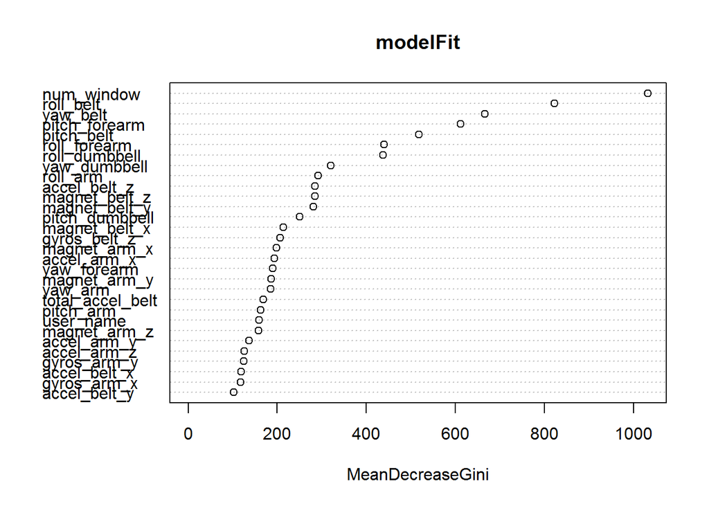

```r
varImpPlot(modelFit, sort=TRUE)
```

Calculate confusion matrix comparing predictions of validation data with their real values.  
We can see accuracy is very high about 0.9976. It’s a good method to predict our data.

```r
#Validate data
confusionMatrix(predict(modelFit,newdata=validationSet),validationSet$classe)
```

```
## Confusion Matrix and Statistics
##
##           Reference
## Prediction    A    B    C    D    E
##          A 2231    4    0    0    0
##          B    0 1514    0    0    0
##          C    0    0 1368    9    0
##          D    1    0    0 1276    4
##          E    0    0    0    1 1438
##
## Overall Statistics
##
##                Accuracy : 0.9976
##                  95% CI : (0.9962, 0.9985)
##     No Information Rate : 0.2845
##     P-Value [Acc > NIR] : < 2.2e-16
##
##                   Kappa : 0.9969
##  Mcnemar's Test P-Value : NA
##
## Statistics by Class:
##
##                      Class: A Class: B Class: C Class: D Class: E
## Sensitivity            0.9996   0.9974   1.0000   0.9922   0.9972
## Specificity            0.9993   1.0000   0.9986   0.9992   0.9998
## Pos Pred Value         0.9982   1.0000   0.9935   0.9961   0.9993
## Neg Pred Value         0.9998   0.9994   1.0000   0.9985   0.9994
## Prevalence             0.2845   0.1935   0.1744   0.1639   0.1838
## Detection Rate         0.2843   0.1930   0.1744   0.1626   0.1833
## Detection Prevalence   0.2849   0.1930   0.1755   0.1633   0.1834
## Balanced Accuracy      0.9994   0.9987   0.9993   0.9957   0.9985
```

### Predictions Results

We prepare testing data and predict them with model.

```r
testing <- testing[, c("user_name", "new_window",  "num_window", "roll_belt", "pitch_belt",
"yaw_belt", "total_accel_belt", "gyros_belt_x", "gyros_belt_y", "gyros_belt_z",
"accel_belt_x", "accel_belt_y", "accel_belt_z", "magnet_belt_x", "magnet_belt_y", "magnet_belt_z",
"roll_arm", "pitch_arm", "yaw_arm", "total_accel_arm", "gyros_arm_x", "gyros_arm_y", "gyros_arm_z",
"accel_arm_x", "accel_arm_y", "accel_arm_z", "magnet_arm_x", "magnet_arm_y", "magnet_arm_z",
"roll_dumbbell", "pitch_dumbbell", "yaw_dumbbell", "roll_forearm", "pitch_forearm",
"yaw_forearm")]
classe<- factor(x="A",levels=c("A", "B", "C", "D", "E"))
testing <- cbind(testing, classe)
testing <- rbind(validationSet[1,],testing)

# Predict data
pred <- predict(modelFit,newdata=testing[-1,])
print(pred)
```

```
## 22  3  4  5  6  7  8  9 10 11 12 13 14 15 16 17 18 19 20 21
##  B  A  B  A  A  E  D  B  A  A  B  C  B  A  E  E  A  B  B  B
## Levels: A B C D E
```

### Annex I:

**Program help you to submit predictions in assigment.**  
Generating Answers Files to Submit Assignment

answers = c(“B”,“A”,“B”,“A”,“A”,“E”,“D”,“B”,“A”,“A”,“B”,“C”,“B”,“A”,“E”,“E”,“A”,“B”,“B”,“B”)

then you can load this function by copying and pasting it into R:  
pml_write_files = function(x){  
n = length(x)  
for(i in 1:n){  
filename = paste0(“problem_id_”,i,“.txt”)  
write.table(x[i],file=filename,quote=FALSE,row.names=FALSE,col.names=FALSE)  
}  
}  
then create a folder where you want the files to be written. Set that to be your working directory and run:  
pml_write_files(answers)